LXG

Above and Beyond.

# 从学习曲线看样本量对模型拟合改善作用

Xinguang Liu

2017年2月7日

## 序言

过年期间重温了*Andrew Ng*的课，期间一个小节中提到了学习曲线对于模型优化的帮助作用，不由得想起日常讨论中经常听到*模拟拟合的不够好，是因为用于训练的数据集不够大，所以需要寻找更多的数据用于优化模拟拟合*类似的话，可模拟拟合的优劣与数据集大小之间真的是正比关系吗？看看模型拟合误差的学习曲线怎么说。

## 模拟数据集

生成以下样本数据，按60/40比例分割为训练集和测试集，cost function定义为误差的标准差。

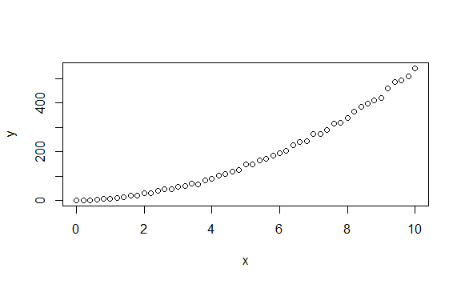

## 模型比较

看三个模型对应的cost随训练样本数增加的学习曲线来分析样本量对模型拟合的作用。

### 模型1：线性模型

```
model <- lm(y ~ x, data = training)
```

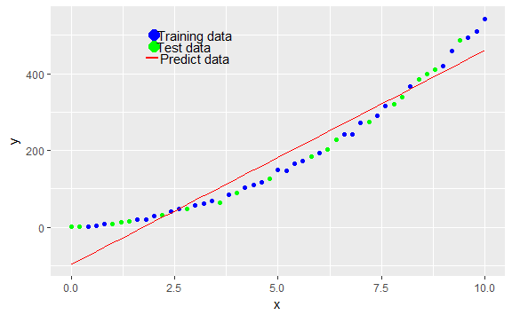

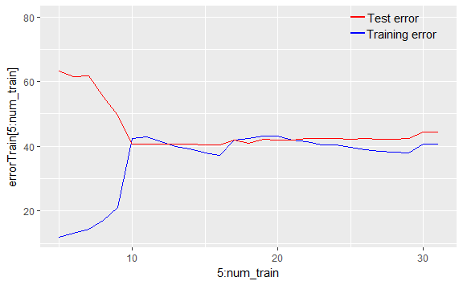

### 模型2：高阶多项式拟合

```
model <- lm(y ~ poly(x, 10), data = training)
```

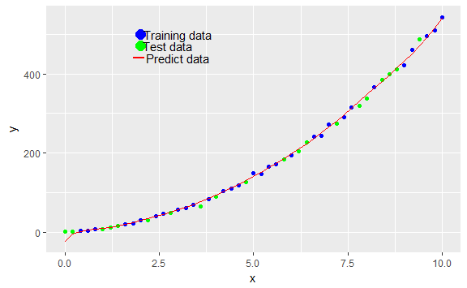

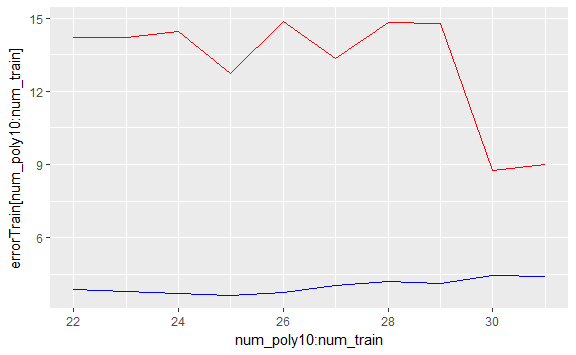

### 模型3：适当的多项式拟合

```
model <- lm(y ~ poly(x, 2), data = training)
```

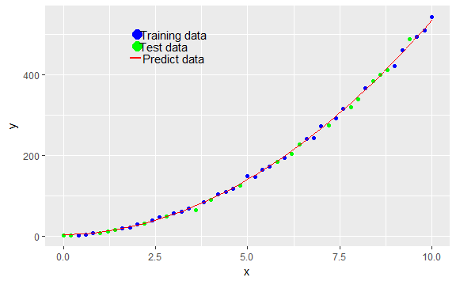

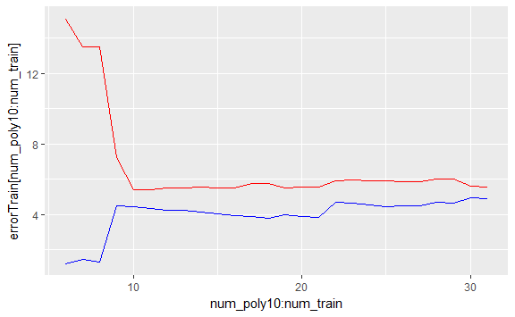

### 模型分析

上面三个模型的拟合`cost function`结果为：

| model | trainingError | testError |
| --- | --- | --- |
| lm | 40.72 | 44.44 |
| poly(x,10) | 4.42 | 8.98 |
| poly(x,2) | 4.88 | 5.55 |

可见：

- 模型1为典型的`underfit`，其训练误差和测试误差都非常大，且两者基本处于同一水平，不随样本量的增加而变化；
- 模型2为典型的`overfit`，其训练误差较小，但测试误差较大，且随着样本数增加两者有趋于一致的趋势（测试误差进一步减小）；
- 模型3为折中模型，其训练误差比模型2略大，但模型复杂度却大幅下降，也抵消了模型2中的`overfit`影响，对应的测试误差比模型2小，模型优势明显，但模型误差在样本量>10之后变化非常小，也就是模型的训练在样本数为10时已完成，后续的样本增加无明显帮助。

## 小结

- 对于`underfit`的模型，单纯增加训练样本数对模型调优无帮助，应该调整模型的复杂度；
- 对于`overfit`的模型，单纯增加训练样本数对模型调优有帮助，可以有效降低测试误差；通过监测其`cost`变化曲线，可以找到所需要的最小样本点；
- 对于复杂度较为“合适”的模型，会在较少的一定量样本后快速趋于稳定，之后再增加训练样本的作用很小。